# Plotting with Base Function

[Nao Mimoto](https://nmimoto.github.io/) - [Dept. of Statistics](http://www.uakron.edu/stat/) : [The University of Akron](http://www.uakron.edu)

[Intro to R Webpage](https://nmimoto.github.io/IntroR/)

## 1. Base Function vs ggplot2

We look at simple plotting with base functions (without using any packages). R has very good visualization package called ggplot2. Tutorial for that is on another page.

## 2. Plotting

```r
Orig <- read.csv("https://nmimoto.github.io/datasets/plants.csv")
                # load the dataset directly from website.
dim(Orig)       # n=32. Ther are 3 columns
```

```
## [1] 32  3
```

```r
names(Orig)     # look up the names of columns
```

```
## [1] "Cost"   "MWatts" "Date"
```

```r
head(Orig)
```

```
##     Cost MWatts  Date
## 1 345.39    514 67.92
## 2 460.05    687 68.58
## 3 452.99   1065 67.33
## 4 443.22   1065 67.33
## 5 652.32   1065 68.00
## 6 642.23   1065 68.00
```

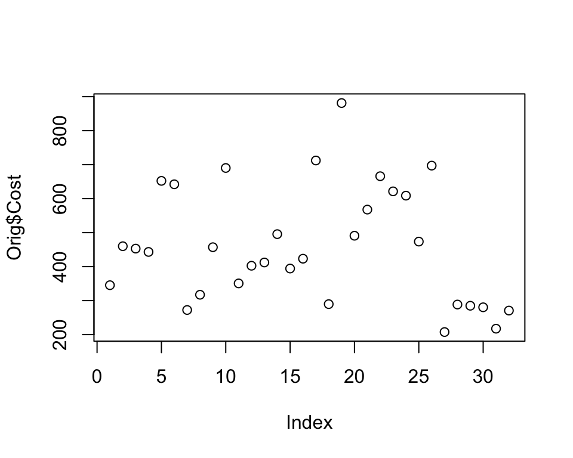

```r
plot(Orig$Cost)       # scatter plot of Cost column
```

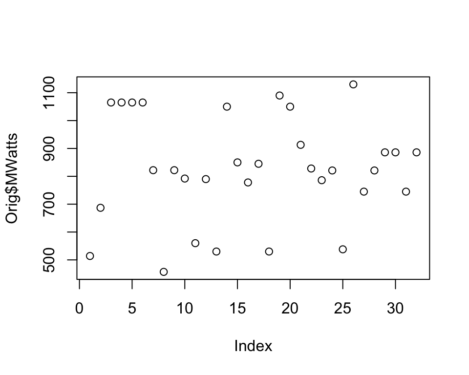

```r
plot(Orig$MWatts)     # scatter plot of MWatts column
```

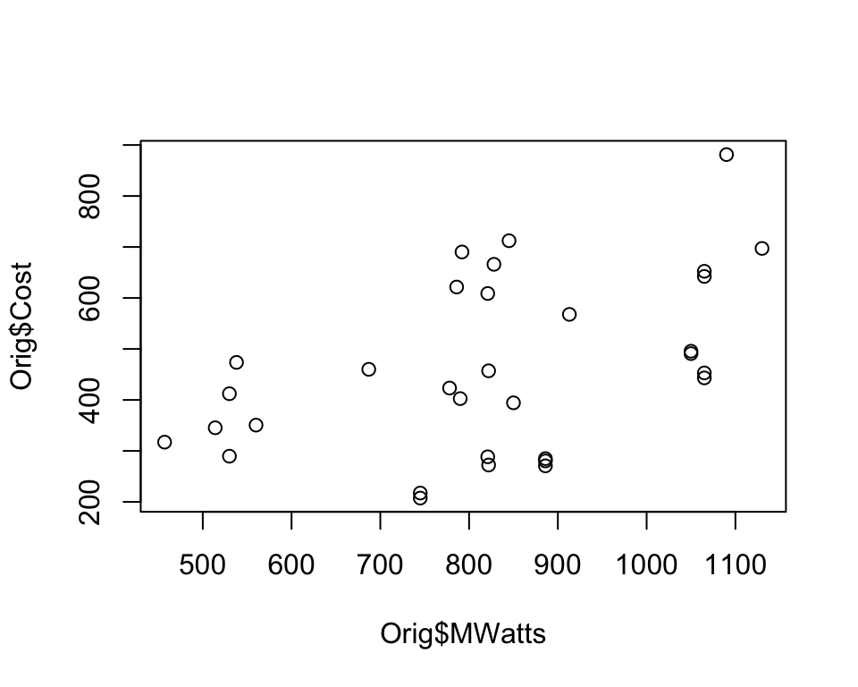

```r
plot(Orig$MWatts, Orig$Cost)    #  MWatts vs Cost
```

Note that MWatts is on x-axis.

## 2. Plotting options

Let’s load **lynx.csv** from my website.

```r
Orig <- read.csv("https://nmimoto.github.io/datasets/lynx.csv")
                # load the dataset directly from website.
head(Orig)      # the data only has one column called "Lynx"
```

```
##   Lynx
## 1  269
## 2  321
## 3  585
## 4  871
## 5 1475
## 6 2821
```

```r
dim(Orig)       # n = 114
```

```
## [1] 114   1
```

```r
X = Orig$Lynx   # Call "Lynx" column of "Orig" data as "X" for convenience.
```

### Plot types

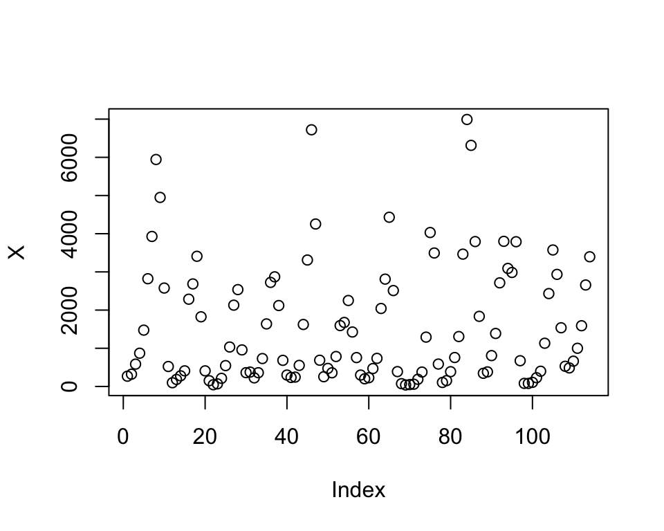

```r
plot(X)               # scatter plot is the default for plot()
plot(X, type="p")     # type="p" gives the same scatter plot
```

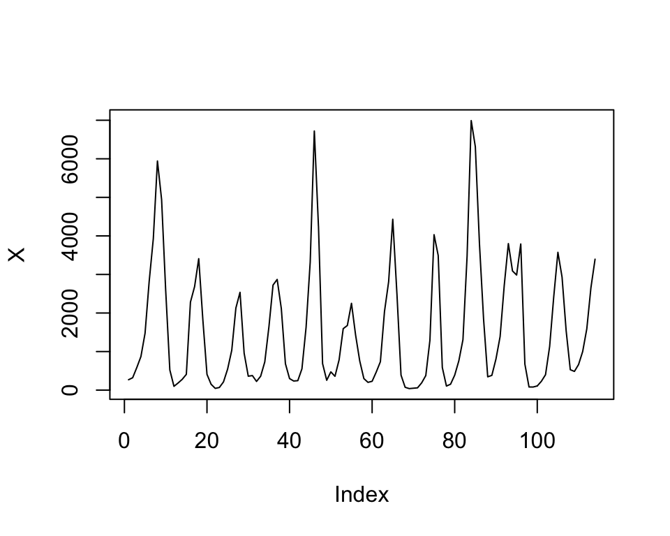

```r
plot(X, type="l")     # line plot
```

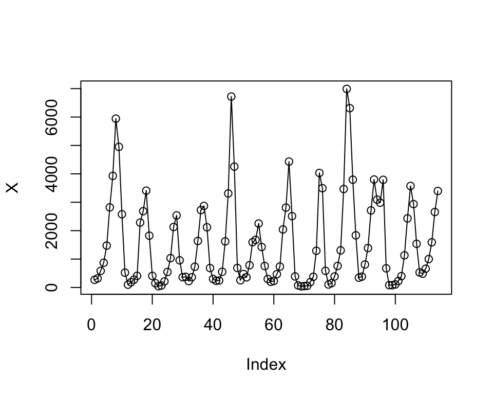

```r
plot(X, type="o")     # both
```

### Change line width

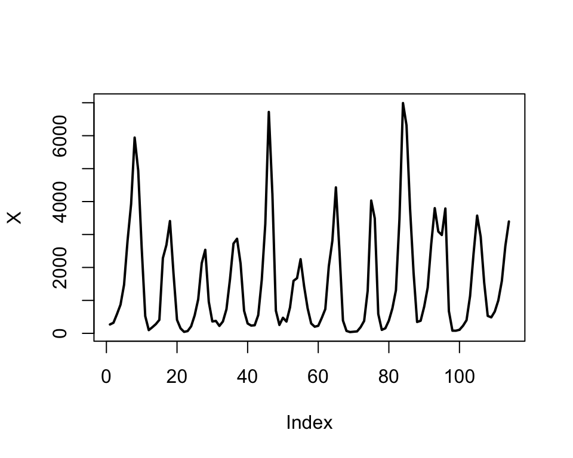

```r
plot(X, type="l", lwd=2)      # thick line
```

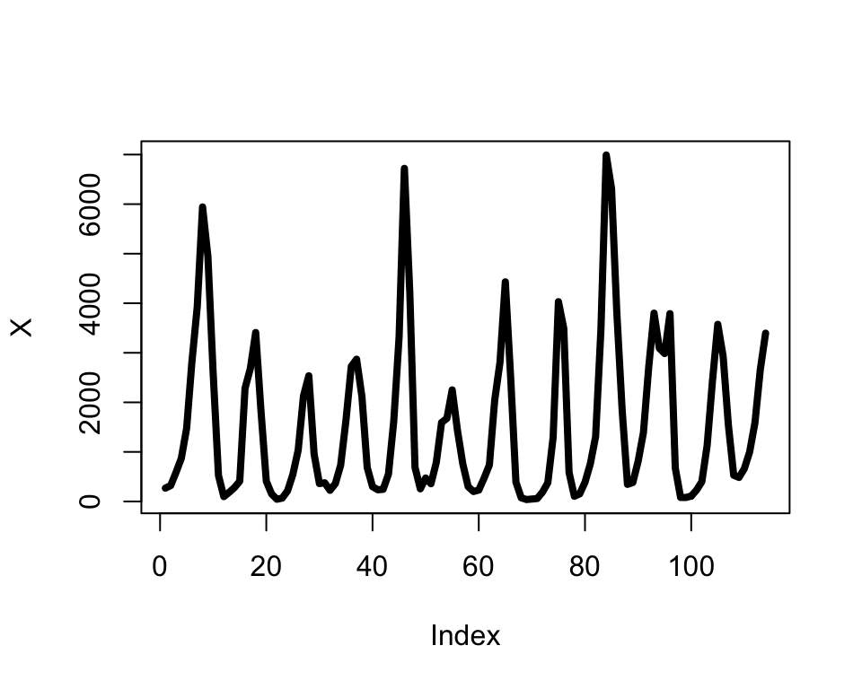

```r
plot(X, type="l", lwd=4)      # thicker line
```

### Change color

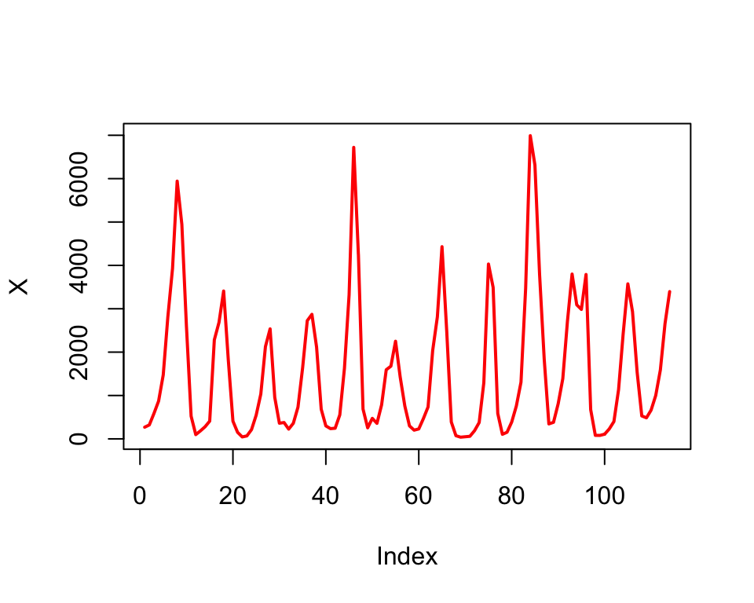

```r
plot(X, type="l", lwd=2, col="red")
```

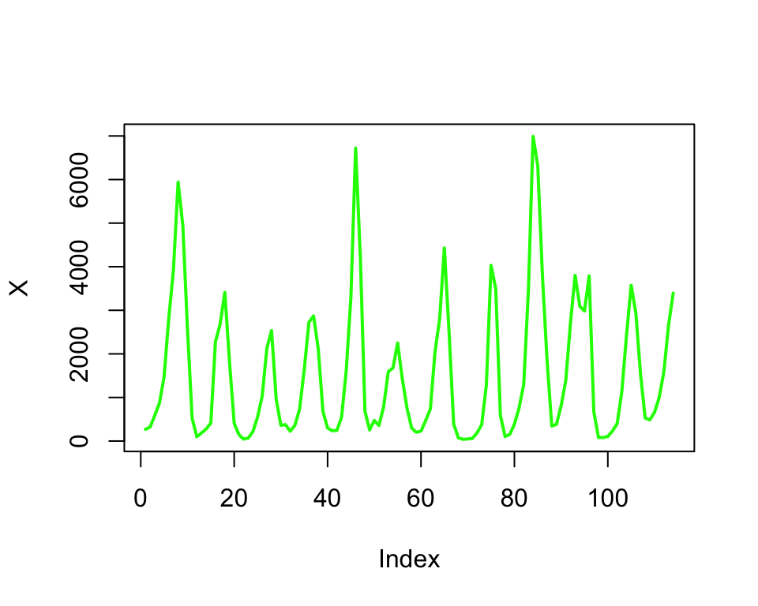

```r
plot(X, type="l", lwd=2, col="green")
```

### Zooming in/out

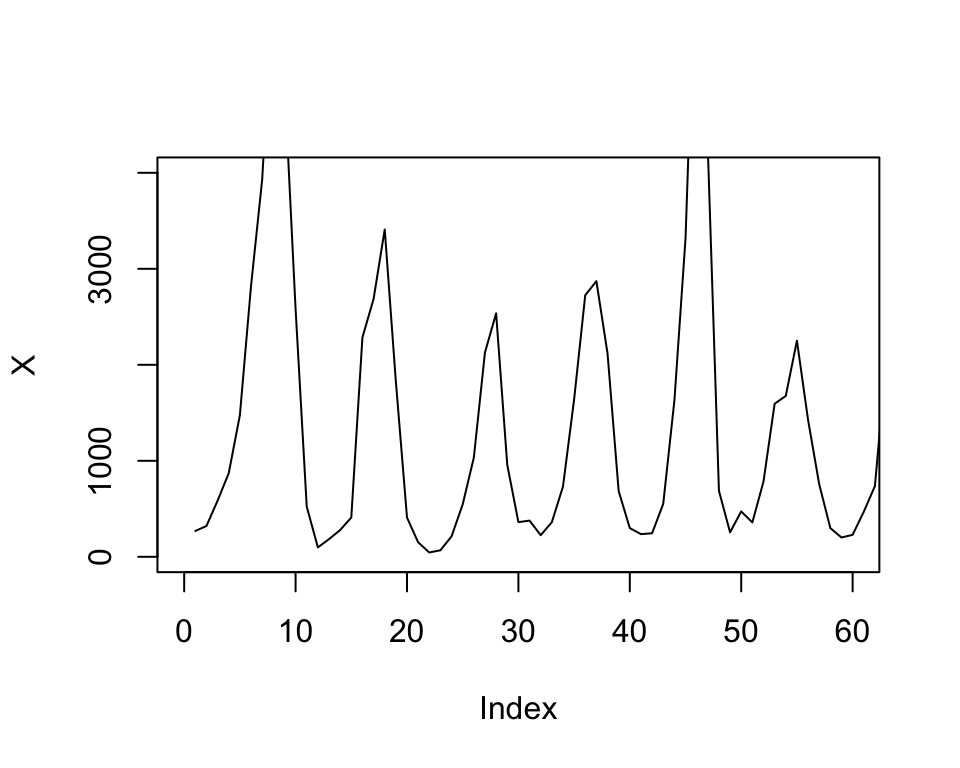

```r
plot(X, type="l", xlim=c(0,60), ylim=c(0,4000))     # Zooming In
```

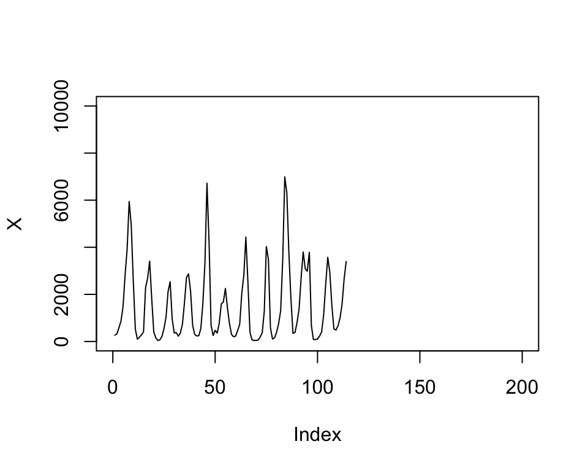

```r
plot(X, type="l", xlim=c(0,200), ylim=c(0,10000))   # Zooming Out
```

### Put title and Label

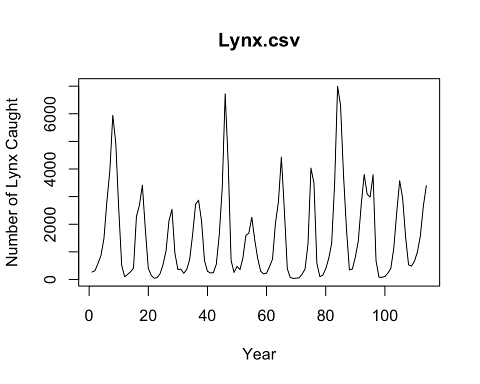

```r
plot(X, type="l",
     xlab="Year", ylab="Number of Lynx Caught",
     main="Lynx.csv")
```

### How to look up more options

Googling something like “R how to change line type” is the best bet. You can also look at R documentation by command:

```r
?plot
```

## 3. Draw lines to Plot

You can add horizontal and vertical lines to existing plot.

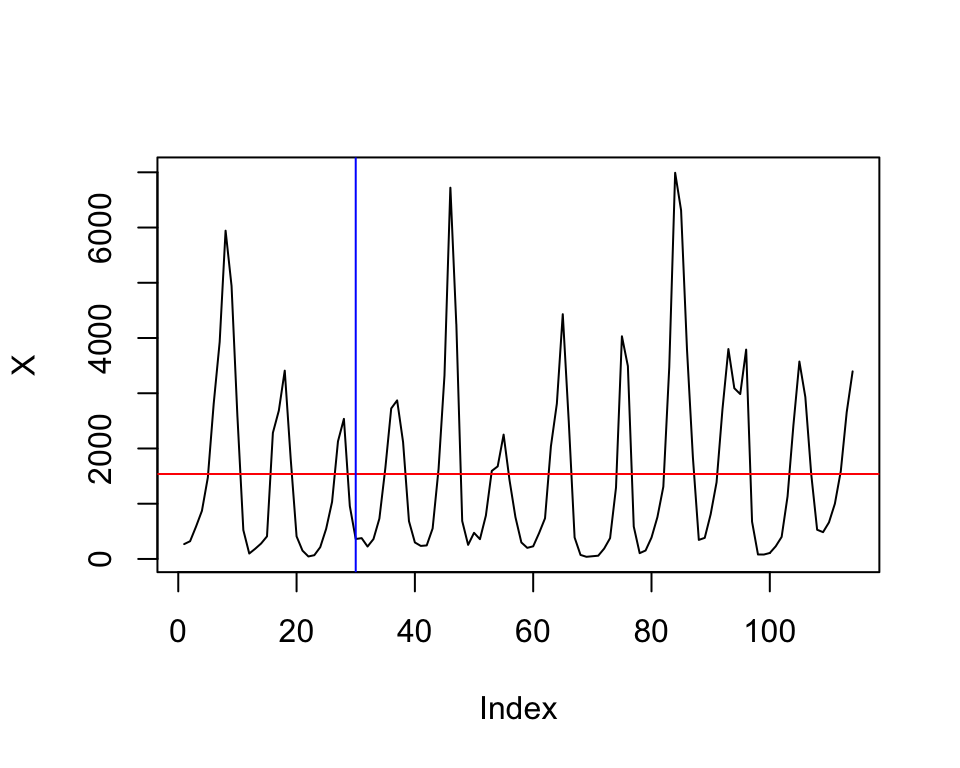

```r
Orig <- read.csv("https://nmimoto.github.io/datasets/lynx.csv")
X = Orig$Lynx

plot(X, type="l")
M = mean(X)
abline(h=M, col="red")    # h for horizontal
abline(v=30, col="blue")  # v for vertical
```

You can also draw line with intercept and slope.

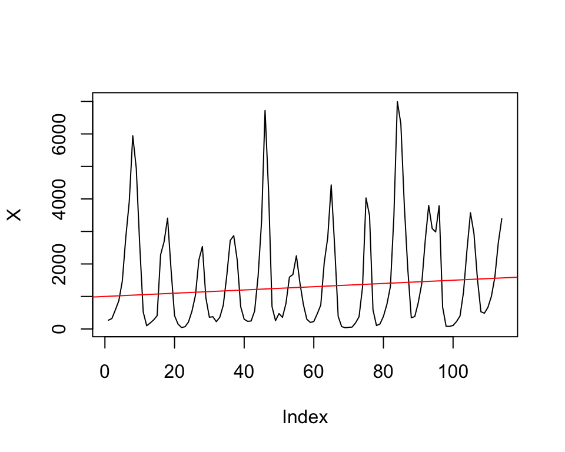

```r
plot(X, type="l")

abline(a=1000, b=5, col="red")    # a=intercept. b=slope
```

## 4. Overlaying Two Plots

```r
Orig2 <- read.csv("https://nmimoto.github.io/datasets/wine.csv")
                   # load in wine.csv from webpage
head(Orig2)        # has 1 column called "wine"
```

```
##   wine
## 1  464
## 2  675
## 3  703
## 4  887
## 5 1139
## 6 1077
```

```r
dim(Orig2)         # n = 142
```

```
## [1] 142   1
```

```r
Y = Orig2$wine     # Call "wine" column as "Y" for convenience.
```

### Single plots

Note that **X** was defined as **Orig$Lynx** above.

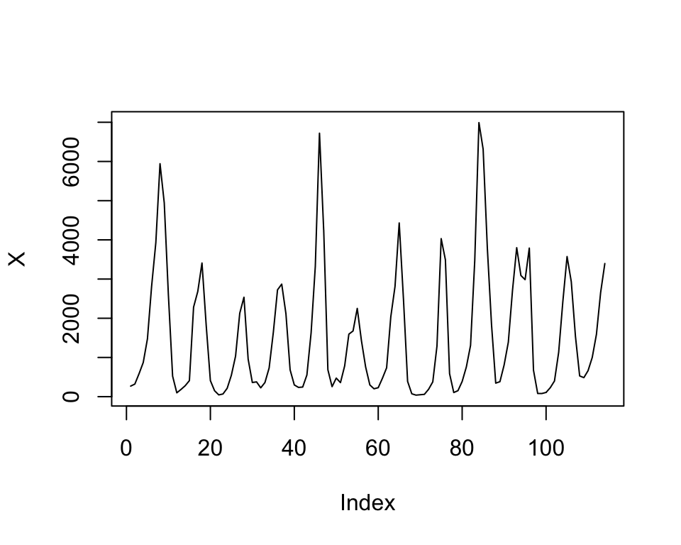

```r
plot(X, type="l")
```

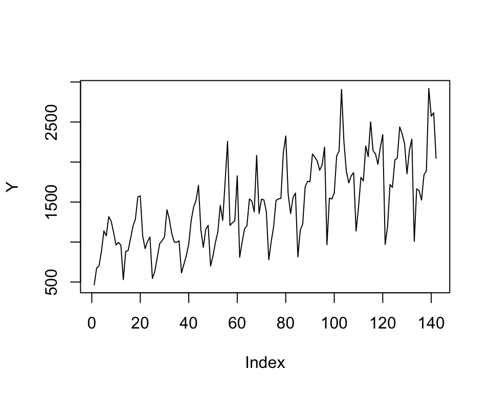

```r
plot(Y, type="l")
```

### Overlay two plots

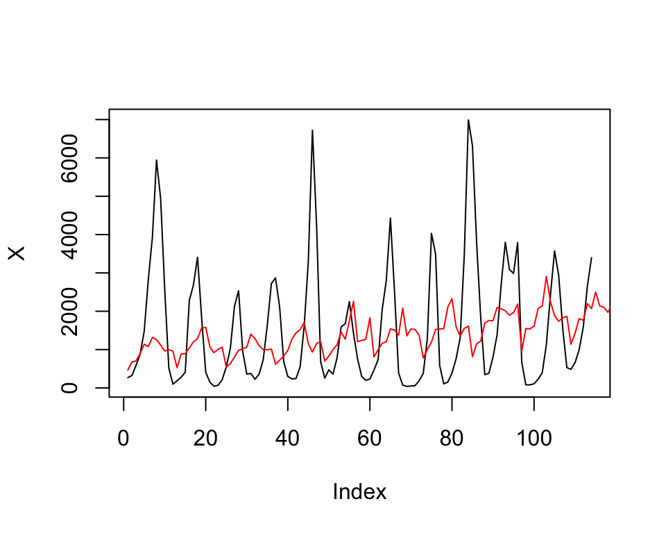

```r
plot(X, type="l")      # plot X on its own
lines(Y, col="red")    # overlay Y
```

Note that **lines()** uses **type=“l”** as default. You can change it by usint **type=** command if you need to.

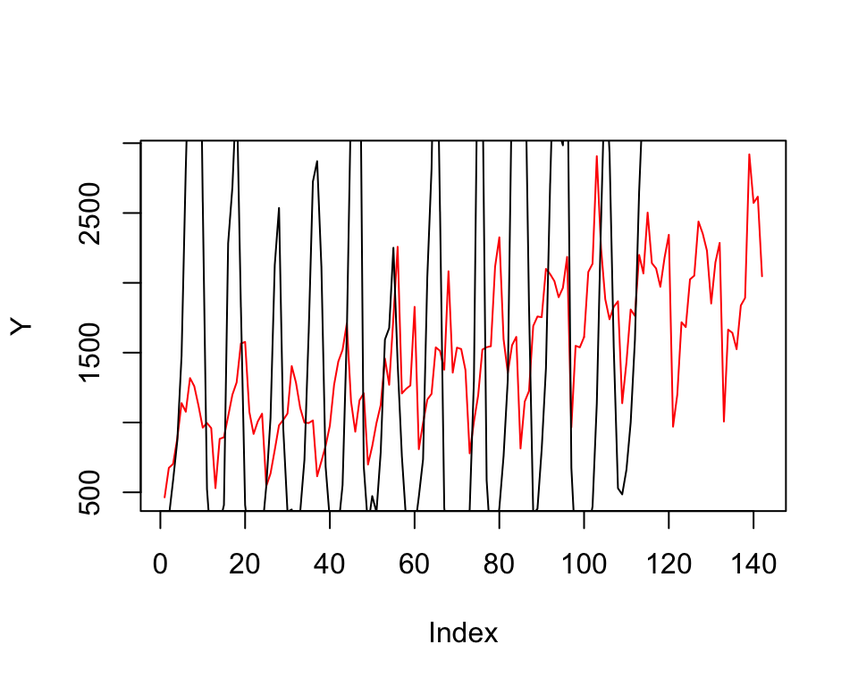

```r
plot(Y, type="l", col="red")     # plot Y on its own
lines(X)                         # overlay X
```

Note that **lines()** use uses the plot that is already drawn by **plot()**. So which one to plot first does matter. You can specify the range of the plot in **plot()**.

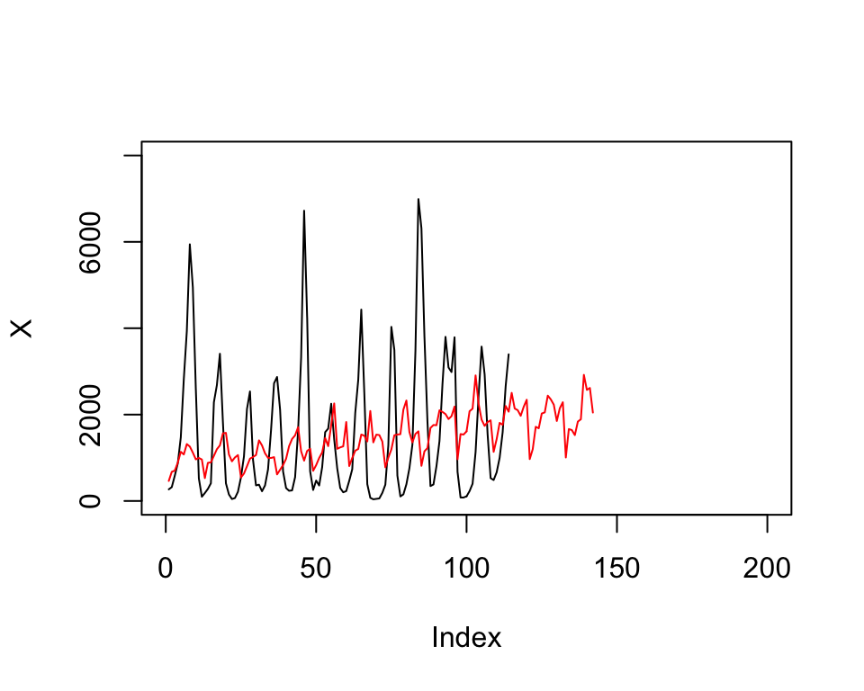

```r
plot(X, type="l", xlim=c(0,200), ylim=c(0, 8000))    # plot X with more range
lines(Y, col="red")                                  # overlay Y
```

## 5. Plotting in Panels

You can plot more than 1 plot on a same page. Here’s horizontal stack.

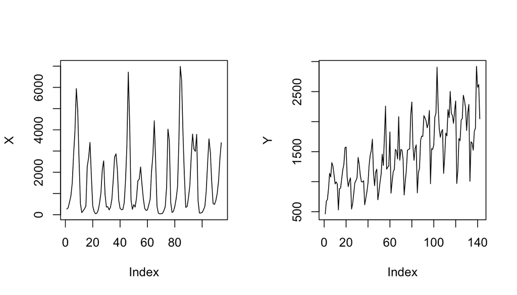

```r
layout(matrix(1:2, 1, 2))    # set up layout as (2x1) matrix
plot(X, type="l")
plot(Y, type="l")
```

```r
layout(1)                    # back to 1 plot layout
```

Vertical stack.

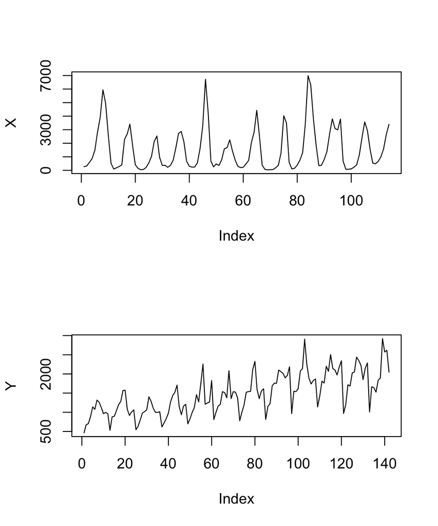

```r
layout(matrix(1:2, 2, 1))    # set up layout as (2x1) matrix
plot(X, type="l")
plot(Y, type="l")
```

```r
layout(1)                    # back to 1 plot layout
```

As 2 by 2 panel.

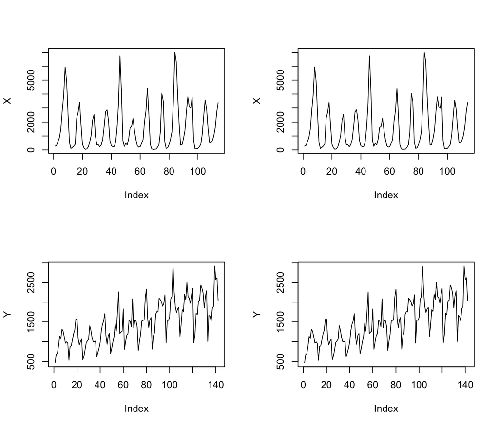

```r
layout(matrix(1:4, 2, 2))    # set up layout as (2x2) matrix
plot(X, type="l")
plot(Y, type="l")
plot(X, type="l")
plot(Y, type="l")
```

```r
layout(1)                    # back to 1 plot layout
```